# Biostat 203B Homework 1

Due Jan 26, 2024 @ 11:59PM

Author

Chengwu Duan (Jason) and 606332825

## Q1. Git/GitHub

**No handwritten homework reports are accepted for this course.** We work with Git and GitHub. Efficient and abundant use of Git, e.g., frequent and well-documented commits, is an important criterion for grading your homework.

1. Apply for the [Student Developer Pack](https://education.github.com/pack) at GitHub using your UCLA email. You’ll get GitHub Pro account for free (unlimited public and private repositories).
2. Create a **private** repository `biostat-203b-2024-winter` and add `Hua-Zhou` and TA team (`Tomoki-Okuno` for Lec 1; `jonathanhori` and `jasenzhang1` for Lec 80) as your collaborators with write permission.
3. Top directories of the repository should be `hw1`, `hw2`, … Maintain two branches `main` and `develop`. The `develop` branch will be your main playground, the place where you develop solution (code) to homework problems and write up report. The `main` branch will be your presentation area. Submit your homework files (Quarto file `qmd`, `html` file converted by Quarto, all code and extra data sets to reproduce results) in the `main` branch.
4. After each homework due date, course reader and instructor will check out your `main` branch for grading. Tag each of your homework submissions with tag names `hw1`, `hw2`, … Tagging time will be used as your submission time. That means if you tag your `hw1` submission after deadline, penalty points will be deducted for late submission.
5. After this course, you can make this repository public and use it to demonstrate your skill sets on job market.

**Answer:** This is the [private repository](https://github.com/Jasonduanchengwu/biostat-203b-2024-winter/tree/main) that I have created.

## Q2. Data ethics training

This exercise (and later in this course) uses the [MIMIC-IV data v2.2](https://physionet.org/content/mimiciv/2.2/), a freely accessible critical care database developed by the MIT Lab for Computational Physiology. Follow the instructions at https://mimic.mit.edu/docs/gettingstarted/ to (1) complete the CITI `Data or Specimens Only Research` course and (2) obtain the PhysioNet credential for using the MIMIC-IV data. Display the verification links to your completion report and completion certificate here. **You must complete Q2 before working on the remaining questions.** (Hint: The CITI training takes a few hours and the PhysioNet credentialing takes a couple days; do not leave it to the last minute.)

**Answer (1):** This is my CITI training on Data or Specimens Only Research [Completion Report](https://www.citiprogram.org/verify/?ka5ed0b04-6377-458d-bf58-03bfcd1a5fa6-60370401) and [Completion Certificate](https://www.citiprogram.org/verify/?w9ffd9891-8edb-4345-af5d-637d9ea54ad0-60370401)

**Answer (2):** Below is my approval for PhysioNet credentials

[figure not shown]

## Q3. Linux Shell Commands

1. Make the MIMIC v2.2 data available at location `~/mimic`.

```bash
ls -l ~/mimic/
```

```
total 24
-rwxrwxrwx 1 jasonduanchengwu jasonduanchengwu 13332 Jan 12 12:46 CHANGELOG.txt
-rwxrwxrwx 1 jasonduanchengwu jasonduanchengwu  2518 Jan 12 12:46 LICENSE.txt
-rwxrwxrwx 1 jasonduanchengwu jasonduanchengwu  2884 Jan 12 12:46 SHA256SUMS.txt
drwxrwxrwx 1 jasonduanchengwu jasonduanchengwu  4096 Jan 12 16:33 hosp
drwxrwxrwx 1 jasonduanchengwu jasonduanchengwu  4096 Jan 12 12:50 icu
```

Refer to the documentation https://physionet.org/content/mimiciv/2.2/ for details of data files. Please, do **not** put these data files into Git; they are big. Do **not** copy them into your directory. Do **not** decompress the gz data files. These create unnecessary big files and are not big-data-friendly practices. Read from the data folder `~/mimic` directly in following exercises.

Use Bash commands to answer following questions.

2. Display the contents in the folders `hosp` and `icu` using Bash command `ls -l`. Why are these data files distributed as `.csv.gz` files instead of `.csv` (comma separated values) files? Read the page https://mimic.mit.edu/docs/iv/ to understand what’s in each folder.

```bash
ls -l ~/mimic/hosp
```

```
total 4429876
-rwxrwxrwx 1 jasonduanchengwu jasonduanchengwu   15516088 Jan 12 12:46 admissions.csv.gz
-rwxrwxrwx 1 jasonduanchengwu jasonduanchengwu     427468 Jan 12 12:46 d_hcpcs.csv.gz
-rwxrwxrwx 1 jasonduanchengwu jasonduanchengwu     859438 Jan 12 12:46 d_icd_diagnoses.csv.gz
-rwxrwxrwx 1 jasonduanchengwu jasonduanchengwu     578517 Jan 12 12:46 d_icd_procedures.csv.gz
-rwxrwxrwx 1 jasonduanchengwu jasonduanchengwu      12900 Jan 12 12:46 d_labitems.csv.gz
-rwxrwxrwx 1 jasonduanchengwu jasonduanchengwu   25070720 Jan 12 12:46 diagnoses_icd.csv.gz
-rwxrwxrwx 1 jasonduanchengwu jasonduanchengwu    7426955 Jan 12 12:46 drgcodes.csv.gz
-rwxrwxrwx 1 jasonduanchengwu jasonduanchengwu  508524623 Jan 12 12:46 emar.csv.gz
-rwxrwxrwx 1 jasonduanchengwu jasonduanchengwu  471096030 Jan 12 12:46 emar_detail.csv.gz
-rwxrwxrwx 1 jasonduanchengwu jasonduanchengwu    1767138 Jan 12 12:47 hcpcsevents.csv.gz
-rwxrwxrwx 1 jasonduanchengwu jasonduanchengwu 1939088924 Jan 12 12:47 labevents.csv.gz
-rwxrwxrwx 1 jasonduanchengwu jasonduanchengwu   96698496 Jan 12 12:47 microbiologyevents.csv.gz
-rwxrwxrwx 1 jasonduanchengwu jasonduanchengwu   36124944 Jan 12 12:47 omr.csv.gz
-rwxrwxrwx 1 jasonduanchengwu jasonduanchengwu    2312631 Jan 12 12:47 patients.csv.gz
-rwxrwxrwx 1 jasonduanchengwu jasonduanchengwu  398753125 Jan 12 12:48 pharmacy.csv.gz
-rwxrwxrwx 1 jasonduanchengwu jasonduanchengwu  498505135 Jan 12 12:48 poe.csv.gz
-rwxrwxrwx 1 jasonduanchengwu jasonduanchengwu   25477219 Jan 12 12:48 poe_detail.csv.gz
-rwxrwxrwx 1 jasonduanchengwu jasonduanchengwu  458817415 Jan 12 12:48 prescriptions.csv.gz
-rwxrwxrwx 1 jasonduanchengwu jasonduanchengwu    6027067 Jan 12 12:48 procedures_icd.csv.gz
-rwxrwxrwx 1 jasonduanchengwu jasonduanchengwu     122507 Jan 12 12:48 provider.csv.gz
-rwxrwxrwx 1 jasonduanchengwu jasonduanchengwu    6781247 Jan 12 12:48 services.csv.gz
-rwxrwxrwx 1 jasonduanchengwu jasonduanchengwu   36158338 Jan 12 12:48 transfers.csv.gz
```

```bash
ls -l ~/mimic/icu
```

```
total 3077984
-rwxrwxrwx 1 jasonduanchengwu jasonduanchengwu      35893 Jan 12 12:50 caregiver.csv.gz
-rwxrwxrwx 1 jasonduanchengwu jasonduanchengwu 2467761053 Jan 12 12:50 chartevents.csv.gz
-rwxrwxrwx 1 jasonduanchengwu jasonduanchengwu      57476 Jan 12 12:50 d_items.csv.gz
-rwxrwxrwx 1 jasonduanchengwu jasonduanchengwu   45721062 Jan 12 12:50 datetimeevents.csv.gz
-rwxrwxrwx 1 jasonduanchengwu jasonduanchengwu    2614571 Jan 12 12:50 icustays.csv.gz
-rwxrwxrwx 1 jasonduanchengwu jasonduanchengwu  251962313 Jan 12 12:50 ingredientevents.csv.gz
-rwxrwxrwx 1 jasonduanchengwu jasonduanchengwu  324218488 Jan 12 12:50 inputevents.csv.gz
-rwxrwxrwx 1 jasonduanchengwu jasonduanchengwu   38747895 Jan 12 12:50 outputevents.csv.gz
-rwxrwxrwx 1 jasonduanchengwu jasonduanchengwu   20717852 Jan 12 12:50 procedureevents.csv.gz
```

**Answer:** These data files are distributed as `.csv.gz` because they are stored as compressed `.csv` files, which is without decompressing like the question stated

3. Briefly describe what Bash commands `zcat`, `zless`, `zmore`, and `zgrep` do.

**Answer:** `zcat` lets users to display contents of compressed files, similar to `cat` it prints the contents out in the terminal.

`zless` allows users to view the contents of the compressed file, similar to the `less` command it opens file in the default text editor (Vi) for Ubuntu.

`zmore` is similar to `zless` but different in the user interface during navigation through the file, `zless` is more like scrolling while `zmore` is like reading documents one page at a time. It is all up to the user’s preference.

`zgrep` similar to grep, allows users to search for text/pattern within a compressed file.

4. (Looping in Bash) What’s the output of the following bash script?

```bash
for datafile in ~/mimic/hosp/{a,l,pa}*.gz
do
  ls -l $datafile
done
```

```
-rwxrwxrwx 1 jasonduanchengwu jasonduanchengwu 15516088 Jan 12 12:46 /home/jasonduanchengwu/mimic/hosp/admissions.csv.gz
-rwxrwxrwx 1 jasonduanchengwu jasonduanchengwu 1939088924 Jan 12 12:47 /home/jasonduanchengwu/mimic/hosp/labevents.csv.gz
-rwxrwxrwx 1 jasonduanchengwu jasonduanchengwu 2312631 Jan 12 12:47 /home/jasonduanchengwu/mimic/hosp/patients.csv.gz
```

**Answer:** These code create a loop which named every `.qz` file that matches the pattern which starts either with ‘a’,‘l’ or ‘pa’ at the start of the name as datafile. and then did a do loop to list all those files with long format details.

Display the number of lines in each data file using a similar loop. (Hint: combine linux commands `zcat <` and `wc -l`.)

**Answer:**

```bash
for file in ~/mimic/hosp/{a,l,pa}*.gz
do
  echo -n "Number of lines in $file: "
  zcat< $file | wc -l
done
```

```
Number of lines in /home/jasonduanchengwu/mimic/hosp/admissions.csv.gz: 431232
Number of lines in /home/jasonduanchengwu/mimic/hosp/labevents.csv.gz: 118171368
Number of lines in /home/jasonduanchengwu/mimic/hosp/patients.csv.gz: 299713
```

5. Display the first few lines of `admissions.csv.gz`. How many rows are in this data file? How many unique patients (identified by `subject_id`) are in this data file? Do they match the number of patients listed in the `patients.csv.gz` file? (Hint: combine Linux commands `zcat <`, `head`/`tail`, `awk`, `sort`, `uniq`, `wc`, and so on.)

```bash
echo "The first 3 rows of admissions.csv.gz: "
zcat < ~/mimic/hosp/admissions.csv.gz | head -n 3
```

```
The first 3 rows of admissions.csv.gz:
subject_id,hadm_id,admittime,dischtime,deathtime,admission_type,admit_provider_id,admission_location,discharge_location,insurance,language,marital_status,race,edregtime,edouttime,hospital_expire_flag
10000032,22595853,2180-05-06 22:23:00,2180-05-07 17:15:00,,URGENT,P874LG,TRANSFER FROM HOSPITAL,HOME,Other,ENGLISH,WIDOWED,WHITE,2180-05-06 19:17:00,2180-05-06 23:30:00,0
10000032,22841357,2180-06-26 18:27:00,2180-06-27 18:49:00,,EW EMER.,P09Q6Y,EMERGENCY ROOM,HOME,Medicaid,ENGLISH,WIDOWED,WHITE,2180-06-26 15:54:00,2180-06-26 21:31:00,0
```

```bash
echo "The number of rows in this data file: "
zcat < ~/mimic/hosp/admissions.csv.gz | wc -l
```

```
The number of rows in this data file:
431232
```

```bash
echo "The number of unique patients: "
zcat < ~/mimic/hosp/admissions.csv.gz | tail -n +2 | awk -F',' '{print $1}' | sort | uniq | wc -l
# csv lines contains header lines for fields as the first line, thus starting from second line
```

```
The number of unique patients:
180733
```

```bash
echo "The number of unique patients in patients.csv.gz: "
zcat < ~/mimic/hosp/patients.csv.gz | tail -n +2 | wc -l
zcat < ~/mimic/hosp/patients.csv.gz | tail -n +2 | awk -F',' '{print $1}'| sort| uniq | wc -l
# shows that they are all unique
```

```
The number of unique patients in patients.csv.gz:
299712
299712
```

**Answer:** They do not match.

6. What are the possible values taken by each of the variable `admission_type`, `admission_location`, `insurance`, and `ethnicity`? Also report the count for each unique value of these variables. (Hint: combine Linux commands `zcat`, `head`/`tail`, `awk`, `uniq -c`, `wc`, and so on; skip the header line.)

**Answer:**

```bash
# zcat < ~/mimic/hosp/admissions.csv.gz | head -n 2 checks the data fields and values

# stored in $6,$8,$10,$13 fields respectively
echo "Possible (counts values) for admission_type: "
zcat < ~/mimic/hosp/admissions.csv.gz | tail -n +2 |awk -F',' '{print $6}'|sort|uniq -c
# sorting makes uniq run faster since data is sorted first
```

```
Possible (counts values) for admission_type:
   6626 AMBULATORY OBSERVATION
  19554 DIRECT EMER.
  18707 DIRECT OBSERVATION
  10565 ELECTIVE
  94776 EU OBSERVATION
 149413 EW EMER.
  52668 OBSERVATION ADMIT
  34231 SURGICAL SAME DAY ADMISSION
  44691 URGENT
```

```bash
echo "Possible (counts values) for admission_location: "
zcat < ~/mimic/hosp/admissions.csv.gz | tail -n +2 |awk -F',' '{print $8}'|sort|uniq -c
```

```
Possible (counts values) for admission_location:
    185 AMBULATORY SURGERY TRANSFER
  10008 CLINIC REFERRAL
 232595 EMERGENCY ROOM
    359 INFORMATION NOT AVAILABLE
   4205 INTERNAL TRANSFER TO OR FROM PSYCH
   5479 PACU
 114963 PHYSICIAN REFERRAL
   7804 PROCEDURE SITE
  35974 TRANSFER FROM HOSPITAL
   3843 TRANSFER FROM SKILLED NURSING FACILITY
  15816 WALK-IN/SELF REFERRAL
```

```bash
echo "Possible (counts values) for insurance: "
zcat < ~/mimic/hosp/admissions.csv.gz | tail -n +2 |awk -F',' '{print $10}'|sort|uniq -c
```

```
Possible (counts values) for insurance:
  41330 Medicaid
 160560 Medicare
 229341 Other
```

```bash
echo "Possible (counts values) for ethnicity/race: "
zcat < ~/mimic/hosp/admissions.csv.gz | tail -n +2 |awk -F',' '{print $13}'|sort|uniq -c
```

```
Possible (counts values) for ethnicity/race:
    919 AMERICAN INDIAN/ALASKA NATIVE
   6156 ASIAN
   1198 ASIAN - ASIAN INDIAN
   5587 ASIAN - CHINESE
    506 ASIAN - KOREAN
   1446 ASIAN - SOUTH EAST ASIAN
   2530 BLACK/AFRICAN
  59959 BLACK/AFRICAN AMERICAN
   4765 BLACK/CAPE VERDEAN
   2704 BLACK/CARIBBEAN ISLAND
   7754 HISPANIC OR LATINO
    437 HISPANIC/LATINO - CENTRAL AMERICAN
    639 HISPANIC/LATINO - COLUMBIAN
    500 HISPANIC/LATINO - CUBAN
```

[output cut: 19 more lines]

7. *To compress, or not to compress. That’s the question.* Let’s focus on the big data file `labevents.csv.gz`. Compare compressed gz file size to the uncompressed file size. Compare the run times of `zcat < ~/mimic/labevents.csv.gz | wc -l` versus `wc -l labevents.csv`. Discuss the trade off between storage and speed for big data files. (Hint: `gzip -dk < FILENAME.gz > ./FILENAME`. Remember to delete the large `labevents.csv` file after the exercise.)

**Answer:**

The bash code below ARE reproducible after regenerating `labevents.csv` file with `gzip -dk hosp/labevents.csv.gz > hosp/labevents.csv`. (Since removed after exercise done)

```bash
echo "File size of labevents.csv.gz and labevents.csv"
# $5 is file size while $9 shows the file, -h is human-readable format
ls -lh ~/mimic/hosp/labevents* | awk '{print $5, $9}'
```

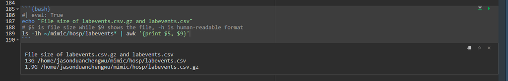

```bash
echo "Run time of labevents.csv.gz"
# $5 is file size while $9 shows the file, -h is human-readable format
time ls -lh ~/mimic/hosp/labevents.csv.gz

echo "Run time of labevents.csv"
time ls -lh ~/mimic/hosp/labevents.csv
```

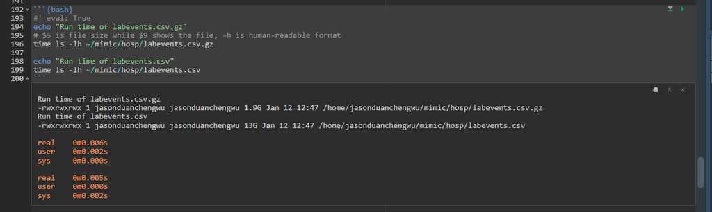

## Q4. Who’s popular in Price and Prejudice

1. You and your friend just have finished reading *Pride and Prejudice* by Jane Austen. Among the four main characters in the book, Elizabeth, Jane, Lydia, and Darcy, your friend thinks that Darcy was the most mentioned. You, however, are certain it was Elizabeth. Obtain the full text of the novel from http://www.gutenberg.org/cache/epub/42671/pg42671.txt and save to your local folder.

```bash
wget -nc -P ~/ http://www.gutenberg.org/cache/epub/42671/pg42671.txt
```

Explain what `wget -nc` does. Do **not** put this text file `pg42671.txt` in Git. Complete the following loop to tabulate the number of times each of the four characters is mentioned using Linux commands.

**Answer:** `wget -nc` downloads a file from the web and `-nc` is a flag to indicate that we do not want to overwrite existing file.

```bash
# -P indicates where to save the file
wget -nc -P ~/ http://www.gutenberg.org/cache/epub/42671/pg42671.txt

# -n allows for outputs to be on the same line
# -o only outputs the matched part and -w is matching the whole word
for char in 'Elizabeth' 'Jane' 'Lydia' 'Darcy'
do
  echo -n "$char: "
  grep -o -w $char ~/pg42671.txt | wc -l
done
```

```
File ‘/home/jasonduanchengwu/pg42671.txt’ already there; not retrieving.

Elizabeth: 634
Jane: 293
Lydia: 170
Darcy: 416
```

Since pg42671.txt may not be present on other machines, image below shows the output of the commands on my machine

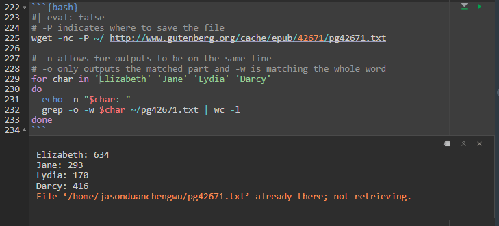

2. What’s the difference between the following two commands?

```bash
echo 'hello, world' > test1.txt
```

and

```bash
echo 'hello, world' >> test2.txt
```

**Answer:** The `>` will overwrite the file if it exists while `>>` will append/add the output to the file. So `echo 'hello, world' > test1.txt` test1.txt will only contain ‘hello, world’ no matter what is originally had while `echo 'hello, world' >> test2.txt` will have “hello, world” attached at the end of what it originally have.

3. Using your favorite text editor (e.g., `vi`), type the following and save the file as `middle.sh`:

```bash
#!/bin/sh
# Select lines from the middle of a file.
# Usage: bash middle.sh filename end_line num_lines
head -n "$2" "$1" | tail -n "$3"
```

Using `chmod` to make the file executable by the owner, and run

```bash
cd ~/biostat-203b_hw/hw1
./middle.sh ~/pg42671.txt 20 5
```

```
Editor: R. W. Chapman

Release date: May 9, 2013 [eBook #42671]

Language: English
```

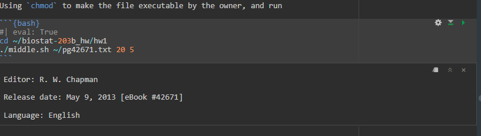

Explain the output. Explain the meaning of `"$1"`, `"$2"`, and `"$3"` in this shell script. Why do we need the first line of the shell script?

**Answer:** `"$1"`, `"$2"`, and `"$3"` refers to the first, second and third argument in the script execution, namely `~/pg42671.txt`, `20` and `5` in this case based on their positions.

`#!/bin/sh` is used to indicate the interpreter to use to execute the script which in this case it is the path to the Bourne shell which is a compatible shell to run the script on. If we do not include the first row, the system would use the default shell to execute the script which lags clarity and may lead to output that user did not intent to have.

The output basically displays the last 5 lines of the first 20 lines of `~/pg42671.txt`.

## Q5. More fun with Linux

Try following commands in Bash and interpret the results: `cal`, `cal 2024`, `cal 9 1752` (anything unusual?), `date`, `hostname`, `arch`, `uname -a`, `uptime`, `who am i`, `who`, `w`, `id`, `last | head`, `echo {con,pre}{sent,fer}{s,ed}`, `time sleep 5`, `history | tail`.

```bash
cal
```

```
    January 2024
Su Mo Tu We Th Fr Sa
    1  2  3  4  5  6
 7  8  9 10 11 12 13
14 15 16 17 18 19 20
21 22 23 24 25 26 27
28 29 30 31
```

**Answer:** `cal` displays the current month calendar

```bash
cal 2024
```

```
                            2024
      January               February               March
Su Mo Tu We Th Fr Sa  Su Mo Tu We Th Fr Sa  Su Mo Tu We Th Fr Sa
    1  2  3  4  5  6               1  2  3                  1  2
 7  8  9 10 11 12 13   4  5  6  7  8  9 10   3  4  5  6  7  8  9
14 15 16 17 18 19 20  11 12 13 14 15 16 17  10 11 12 13 14 15 16
21 22 23 24 25 26 27  18 19 20 21 22 23 24  17 18 19 20 21 22 23
28 29 30 31           25 26 27 28 29        24 25 26 27 28 29 30
                                            31

       April                  May                   June
Su Mo Tu We Th Fr Sa  Su Mo Tu We Th Fr Sa  Su Mo Tu We Th Fr Sa
    1  2  3  4  5  6            1  2  3  4                     1
 7  8  9 10 11 12 13   5  6  7  8  9 10 11   2  3  4  5  6  7  8
14 15 16 17 18 19 20  12 13 14 15 16 17 18   9 10 11 12 13 14 15
21 22 23 24 25 26 27  19 20 21 22 23 24 25  16 17 18 19 20 21 22
28 29 30              26 27 28 29 30 31     23 24 25 26 27 28 29
                                            30

        July                 August              September
Su Mo Tu We Th Fr Sa  Su Mo Tu We Th Fr Sa  Su Mo Tu We Th Fr Sa
    1  2  3  4  5  6               1  2  3   1  2  3  4  5  6  7
 7  8  9 10 11 12 13   4  5  6  7  8  9 10   8  9 10 11 12 13 14
14 15 16 17 18 19 20  11 12 13 14 15 16 17  15 16 17 18 19 20 21
21 22 23 24 25 26 27  18 19 20 21 22 23 24  22 23 24 25 26 27 28
28 29 30 31           25 26 27 28 29 30 31  29 30


      October               November              December
Su Mo Tu We Th Fr Sa  Su Mo Tu We Th Fr Sa  Su Mo Tu We Th Fr Sa
       1  2  3  4  5                  1  2   1  2  3  4  5  6  7
 6  7  8  9 10 11 12   3  4  5  6  7  8  9   8  9 10 11 12 13 14
13 14 15 16 17 18 19  10 11 12 13 14 15 16  15 16 17 18 19 20 21
20 21 22 23 24 25 26  17 18 19 20 21 22 23  22 23 24 25 26 27 28
27 28 29 30 31        24 25 26 27 28 29 30  29 30 31
```

**Answer:** `cal 2024` shows the calendar of year 2024

```bash
cal 9 1752
```

```
   September 1752
Su Mo Tu We Th Fr Sa
       1  2 14 15 16
17 18 19 20 21 22 23
24 25 26 27 28 29 30
```

**Answer:** `cal 9 1752` shows september(9th month) calendar of 1752. There is a historic adjustment specific to the transition to the Gregorian calendar and is not the standard calendar behavior.

```bash
date
```

```
Fri Jan 26 13:53:20 PST 2024
```

**Answer:** show the current day, date, time, timezone and year of point of execution

```bash
hostname
```

```
DESKTOP-NFK2KUS
```

**Answer:** show the current host/system name

```bash
arch
```

```
x86_64
```

**Answer:** shows system architecture which essentially is the machine hardware name.

```bash
uname -a
```

```
Linux DESKTOP-NFK2KUS 5.15.133.1-microsoft-standard-WSL2 #1 SMP Thu Oct 5 21:02:42 UTC 2023 x86_64 x86_64 x86_64 GNU/Linux
```

**Answer:** shows system information and `-a` flag refers to all. It will show the operating system, hostname of machine, kernel version, more information of the kernal and built date, machine hardware name (architecture), processor architecture and indication for system running of Linux kernel

```bash
uptime
```

```
 13:53:20 up  1:42,  1 user,  load average: 0.92, 0.47, 0.26
```

**Answer:** shows the current time, how long the system has been up and running, how many users, and the load average. Load average essentially is the average number of processes in the run queue over the specific time periods, which in this case is 1,5, and 15 minutes respectively

```bash
who am i
```

**Answer:** typically shows the user name, the terminal line asscociated with the session, login timestamp and the display number, however in this case, since we are running this command in a script or WSL, there is no output since WSL works slightly differently than linux, this command does not work on ubuntu terminal as well.

```bash
who
```

```
jasonduanchengwu pts/1        2024-01-26 11:13
```

**Answer:** shows kinda the same informations as who am i but `who` lists all users who are currently logged in while `who am i` focuses on the current user’s terminal session.

```bash
w
```

```
 13:53:20 up  1:42,  1 user,  load average: 0.92, 0.47, 0.26
USER     TTY      FROM             LOGIN@   IDLE   JCPU   PCPU WHAT
jasondua pts/1    -                11:13    2:39m  0.02s  0.02s -bash
```

**Answer:** shows the currently logged in users and the processes, it includes username, terminal, source ip address, time of login, idle time, total CPU time used, percentage CPU time used, and information about current activities. It seems to show the uptime additionally too.

```bash
id
```

```
uid=1000(jasonduanchengwu) gid=1000(jasonduanchengwu) groups=1000(jasonduanchengwu),4(adm),20(dialout),24(cdrom),25(floppy),27(sudo),29(audio),30(dip),44(video),46(plugdev),116(netdev),1001(docker)
```

**Answer:** it shows the user’s userid, group id ,and ids of the groups that the user is a member of.

```bash
last
```

[output not shown]

[output cut: 13 more lines]

[output not shown]

**Answer:** shows a list of recent logins, reboots or shutdowns with username, source IP, login time and session duration.

```bash
head
```

**Answer:** just shows the first indicated number of lines of a file or output.

```bash
echo {con,pre}{sent,fer}{s,ed}
```

```
consents consented confers confered presents presented prefers prefered
```

**Answer:** prints all the possible combination of concatenations the different braces can form.

```bash
time sleep 5
```

```
real    0m5.002s
user    0m0.001s
sys 0m0.000s
```

**Answer:** This times the time taken for the sleep command to delay 5 seconds which logically it will show around 5 seconds. sleep command could be useful for automation scripting where waiting is required for the next input.

```bash
history | tail
```

**Answer:** This will display the last few commands from my command history, while this will not work in a script like environment as scripts are non-interactive. However this works in Terminal, the output is below:

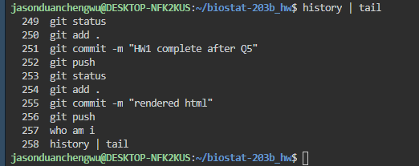

## Q6. Book

1. Git clone the repository https://github.com/christophergandrud/Rep-Res-Book for the book *Reproducible Research with R and RStudio* to your local machine.
2. Open the project by clicking `rep-res-3rd-edition.Rproj` and compile the book by clicking `Build Book` in the `Build` panel of RStudio. (Hint: I was able to build `git_book` and `epub_book` but not `pdf_book`.)

The point of this exercise is (1) to get the book for free and (2) to see an example how a complicated project such as a book can be organized in a reproducible way.

For grading purpose, include a screenshot of Section 4.1.5 of the book here.

**Answer:** Below is my screenshot of section 4.1.5 of the book

[figure not shown]